# Bayesian modeling and prediction for movies

## Setup

### Load packages

```r
library(ggplot2)
library(dplyr)
library(statsr)
library(BAS)
```

```r
load("movies.Rdata")
```

## Part 1: Data

The data is randomly sampled . 651 random samples of movies produced and released before 2016 were taken and they were augmented with ratings information from IMDB and Rotten Tomatoes . I can generalize the inferences made from this dataset to all movies that were produced and released before 2016 .

The data is not randomly assigned . There is no notion of treatment and control groups , this is only an observational study . Hence causal analysis is not possible .

Reservations : It is very likely that not all movies produced and released would have had reviews in rotten tomatoes and imdb , it isn’t very clear if the data was chosen from a subset that had such reviews , if this is case then the generalization would be good only if that number of movies not covered by such sites is small .

## Part 2: Data manipulation

```r
movies <- mutate(movies,feature_film=factor(ifelse(title_type == "Feature Film","yes","no"),levels = c("yes","no")),drama = factor(ifelse(genre == "Drama","yes","no"),levels =c("yes","no")),mpaa_rating_R = factor(ifelse(mpaa_rating == "R","yes","no"),levels =c("yes","no")),oscar_season = factor(ifelse(thtr_rel_month <= 12 & thtr_rel_month >=10,"yes","no"),levels =c("yes","no")),summer_season = factor(ifelse(thtr_rel_month>=5 & thtr_rel_month<=8,"yes","no"),levels =c("yes","no")))

movies_subset <- subset(movies,select = c("audience_score","feature_film","drama","mpaa_rating_R","oscar_season","summer_season"))

summary(movies_subset)
```

```
##  audience_score  feature_film drama     mpaa_rating_R oscar_season
##  Min.   :11.00   yes:591      yes:305   yes:329       yes:191
##  1st Qu.:46.00   no : 60      no :346   no :322       no :460
##  Median :65.00
##  Mean   :62.36
##  3rd Qu.:80.00
##  Max.   :97.00
##  summer_season
##  yes:208
##  no :443
##
##
##
##
```

## Part 3: Exploratory data analysis

```r
#bucketing audience score in 11 levels
movies_subset<- mutate(movies_subset,scoring_class = as.factor(as.integer(movies$audience_score / 10)))
```

#### Impact of being a non feature film on audience score

```r
summary(movies_subset$feature_film)
```

```
## yes  no
## 591  60
```

```r
summary(movies_subset$audience_score[movies_subset$feature_film == "yes"])
```

```
##    Min. 1st Qu.  Median    Mean 3rd Qu.    Max.
##   11.00   44.50   62.00   60.47   78.00   97.00
```

```r
summary(movies_subset$audience_score[movies_subset$feature_film == "no"])
```

```
##    Min. 1st Qu.  Median    Mean 3rd Qu.    Max.
##   19.00   76.50   85.50   81.05   89.00   96.00
```

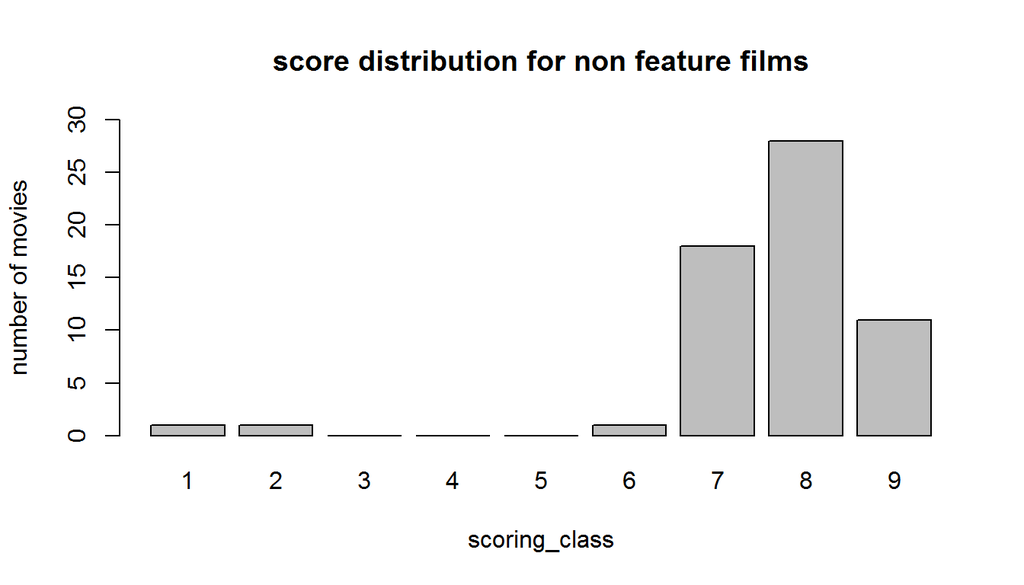

```r
movies_subset_feature_film <- movies_subset %>% group_by(scoring_class) %>% summarize(yeses = sum(feature_film == "yes"),nos = sum(feature_film == "no"))

barplot(movies_subset_feature_film$nos,xlab = "scoring_class",names.arg = 1:9,ylim = c(0,30),main = "score distribution for non feature films", ylab = "number of movies")
```

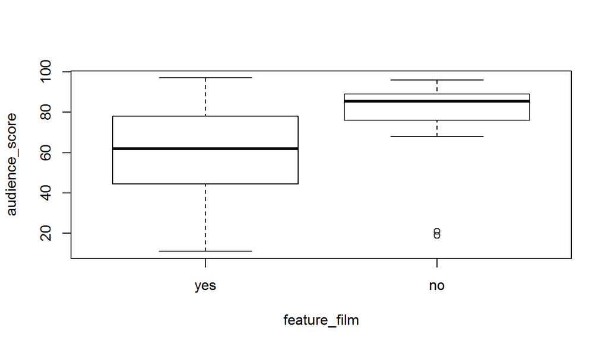

```r
plot(movies_subset$feature_film,movies_subset$audience_score,xlab="feature_film",ylab="audience_score")
```

###### Narrative :

Approximately 90.8%(591 entries) of the movies in the dataset are classified as feature_films , hence one needs to contrast the audience score of non feature films with the audience score show above .

Non feature films have a much higher average rating compared to their feature film counterparts and this variable will have a significant impact on the final model

The score distribution for non feature film is roughly concentrated around 80% with a very long and extremely light left tail . This can either indicate outliers or the presence of another variable that has a higher wt/significance than this one .

#### Impact of being a drama on audience score

```r
summary(movies_subset$drama)
```

```
## yes  no
## 305 346
```

```r
summary(movies_subset$audience_score[movies_subset$drama == "yes"])
```

```
##    Min. 1st Qu.  Median    Mean 3rd Qu.    Max.
##   13.00   52.00   70.00   65.35   80.00   95.00
```

```r
summary(movies_subset$audience_score[movies_subset$drama == "no"])
```

```
##    Min. 1st Qu.  Median    Mean 3rd Qu.    Max.
##   11.00   41.00   61.00   59.73   79.00   97.00
```

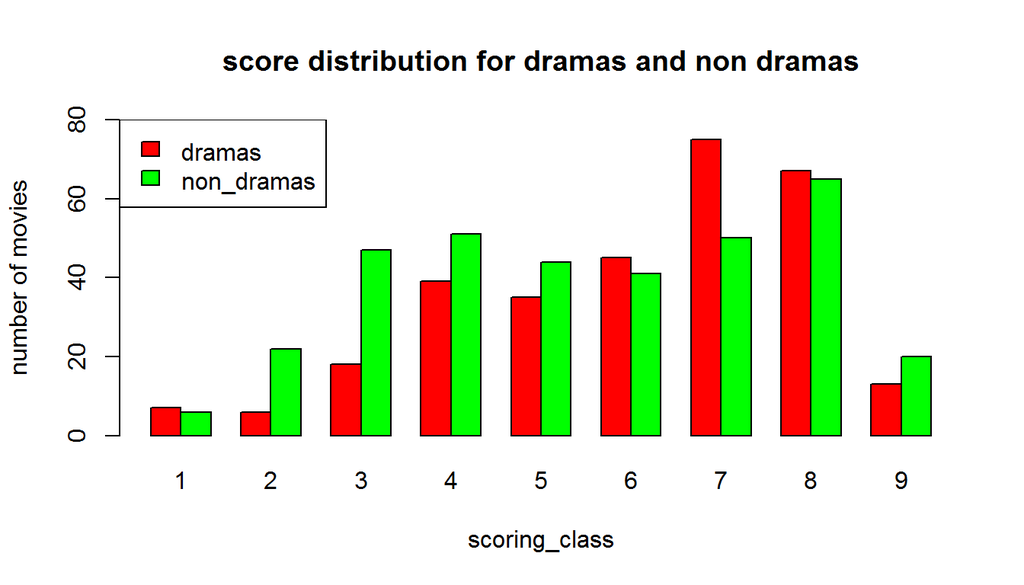

```r
movies_subset_drama <- subset(movies_subset %>% group_by(scoring_class) %>% summarize(dramas = sum(drama == "yes"),non_dramas = sum(drama == "no")),select = c("dramas","non_dramas"))


barplot(t(movies_subset_drama),beside=TRUE,col = c("red","green"),xlab = "scoring_class",names.arg = 1:9,ylim = c(0,80),main = "score distribution for dramas and non dramas", ylab = "number of movies")
legend('topleft',colnames(movies_subset_drama),fill = c("red","green"),adj = c(0, 0.6))
```

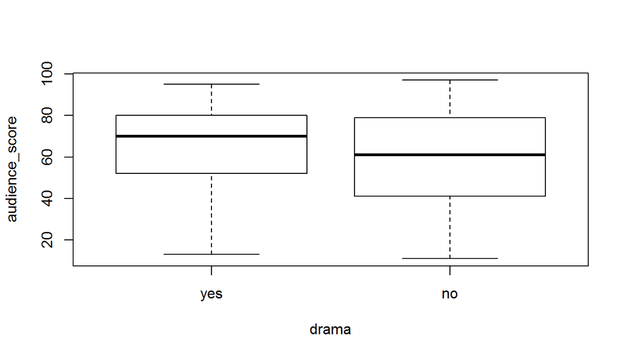

```r
plot(movies_subset$drama,movies_subset$audience_score,xlab="drama",ylab="audience_score")
```

###### Narrative :

I can see that a drama on average have slightly higher scores than non dramas and also have lower spreads.

The distribution for dramas is also negatively skewed .

The IQR for dramas is also smaller than the non dramas and their values are higher indicating that a drama is more likely to get a higher score .

#### Impact of being R Rated on audience score

```r
summary(movies_subset$mpaa_rating_R)
```

```
## yes  no
## 329 322
```

```r
summary(movies_subset$audience_score[movies_subset$mpaa_rating_R == "yes"])
```

```
##    Min. 1st Qu.  Median    Mean 3rd Qu.    Max.
##   14.00   44.00   64.00   62.04   79.00   97.00
```

```r
summary(movies_subset$audience_score[movies_subset$mpaa_rating_R == "no"])
```

```
##    Min. 1st Qu.  Median    Mean 3rd Qu.    Max.
##   11.00   48.25   65.50   62.69   80.00   96.00
```

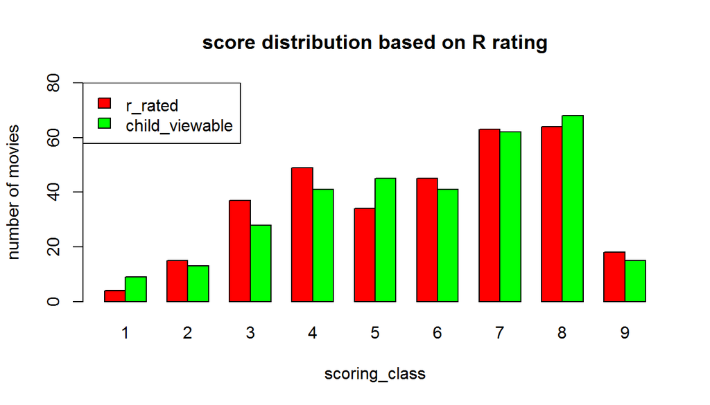

```r
movies_subset_R <- subset(movies_subset %>% group_by(scoring_class) %>% summarize(r_rated = sum(mpaa_rating_R == "yes"),child_viewable = sum(mpaa_rating_R == "no")),select = c("r_rated","child_viewable"))

barplot(t(movies_subset_R),beside=TRUE,col = c("red","green"),xlab = "scoring_class",names.arg = 1:9,ylim = c(0,80),main = "score distribution based on R rating", ylab = "number of movies")
legend('topleft',colnames(movies_subset_R),fill = c("red","green"),adj = c(0, 0.6))
```

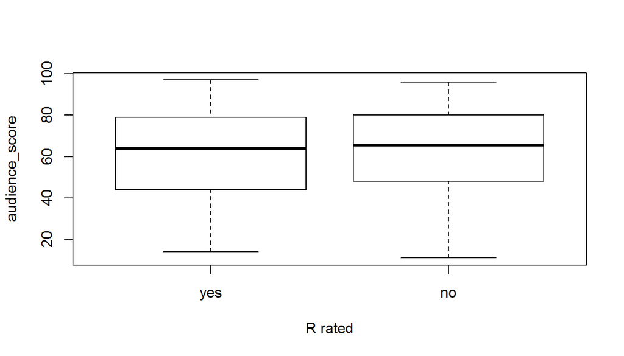

```r
plot(movies_subset$mpaa_rating_R,movies_subset$audience_score,xlab="R rated",ylab="audience_score")
```

###### Narrative :

There is a neary 50-50 ratio of a movie being R rated or not in the sample dataset . There is very little difference in the mean/median/IQR values between R rated and non-R rated movies indicating a low contribution towards the model.

#### Impact of season of release on audience scores

```r
#percentage of movies released during special months
(sum(movies_subset$oscar_season=="yes")+sum(movies_subset$summer_season=="yes"))/651*100
```

```
## [1] 61.29032
```

```r
#stats for oscar season movies
summary(movies_subset$audience_score[movies_subset$oscar_season == "yes"])
```

```
##    Min. 1st Qu.  Median    Mean 3rd Qu.    Max.
##   13.00   47.50   69.00   63.69   81.00   97.00
```

```r
#stats for summer season movies
summary(movies_subset$audience_score[movies_subset$summer_season == "yes"])
```

```
##    Min. 1st Qu.  Median    Mean 3rd Qu.    Max.
##   11.00   44.75   65.00   61.81   78.00   94.00
```

```r
#stats for movies that were released in other months
summary(movies_subset$audience_score[movies_subset$summer_season == "no" & movies_subset$oscar_season == "no" ])
```

```
##    Min. 1st Qu.  Median    Mean 3rd Qu.    Max.
##   14.00   46.00   63.00   61.82   80.00   96.00
```

```r
#stats for movies that were released in these special months
summary(movies_subset$audience_score[movies_subset$summer_season == "yes" | movies_subset$oscar_season == "yes" ])
```

```
##    Min. 1st Qu.  Median    Mean 3rd Qu.    Max.
##   11.00   46.00   66.00   62.71   79.00   97.00
```

[figure not shown]

```r
movies_subset_monthly <- subset(movies_subset %>% group_by(scoring_class) %>% summarize(oscar_release = sum(oscar_season == "yes"),summer_release = sum(summer_season == "no"),normal_months = sum(oscar_season == "no" & summer_season == "no")),select = c("oscar_release","summer_release","normal_months"))


barplot(t(movies_subset_monthly),beside=TRUE,col = c("red","green","blue"),xlab = "scoring_class",names.arg = 1:9,ylim = c(0,100),main = "score distribution based on release season", ylab = "number of movies")
legend('topleft',colnames(movies_subset_monthly),fill = c("red","green","blue"),adj = c(0, 0.6))
```

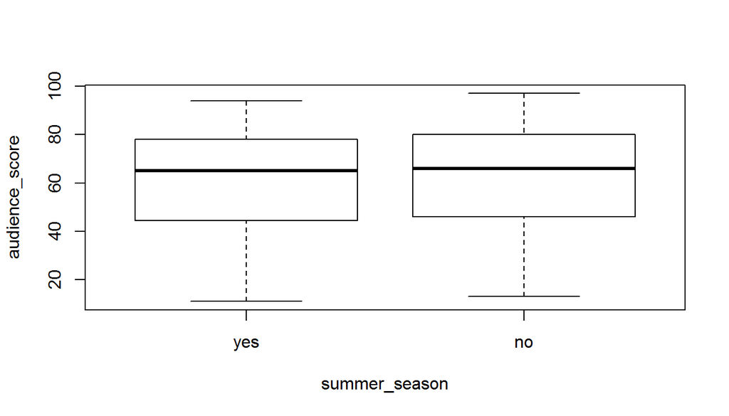

```r
plot(movies_subset$summer_season,movies_subset$audience_score,xlab="summer_season",ylab="audience_score")
```

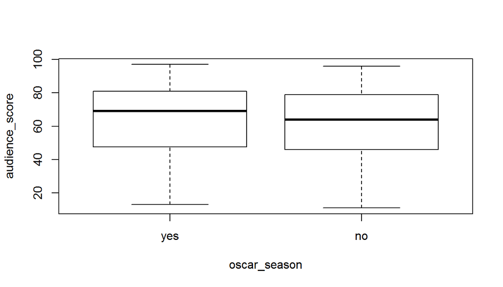

```r
plot(movies_subset$oscar_season,movies_subset$audience_score,xlab="oscar_season",ylab="audience_score")
```

###### Narrative

There is a higer percentage of movies that released during these “special” motnhs .

The movies that are released in these special months outperform their normal month counterparts by a very slim margin.

Digging deeper , the oscar season movies perform better than the normal month movies and the performance of summer month movies is comparable to the performance of normal month movies if not slightly lower .

I can also see from the box plot that the median/IQR for both values of summer_season to be very similar and it migh not contribute much to the model .

#### Impact of best picture nominations/wins on audience scores

```r
summary(movies$best_pic_win)
```

```
##  no yes
## 644   7
```

```r
summary(movies$best_pic_nom)
```

```
##  no yes
## 629  22
```

```r
summary(movies$audience_score[movies$best_pic_win=="yes"])
```

```
##    Min. 1st Qu.  Median    Mean 3rd Qu.    Max.
##   69.00   82.00   84.00   84.71   89.50   97.00
```

```r
summary(movies$audience_score[movies$best_pic_nom=="yes"])
```

```
##    Min. 1st Qu.  Median    Mean 3rd Qu.    Max.
##   69.00   81.00   86.50   85.32   90.50   97.00
```

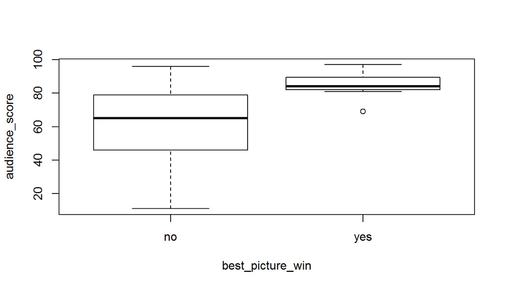

```r
plot(movies$best_pic_win,movies$audience_score,xlab="best_picture_win",ylab="audience_score")
```

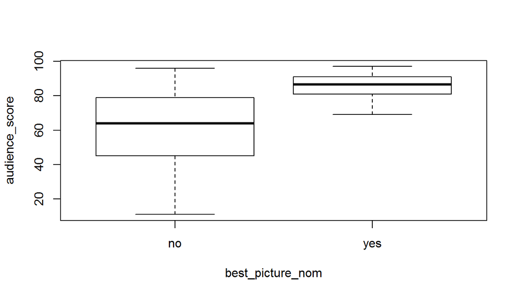

```r
plot(movies$best_pic_nom,movies$audience_score,xlab="best_picture_nom",ylab="audience_score")
```

###### Narrative

I see that having a nomination or winning the award drastically increases the audience score of the movie .

The summary statistics for best_pic_win and best_pic_nom are extremely close and suggest they contain redundant information . It is better to choose best_pic_nom in that case as it contains more positive observations .

#### Impact of best actor/actress/director win on audience scores

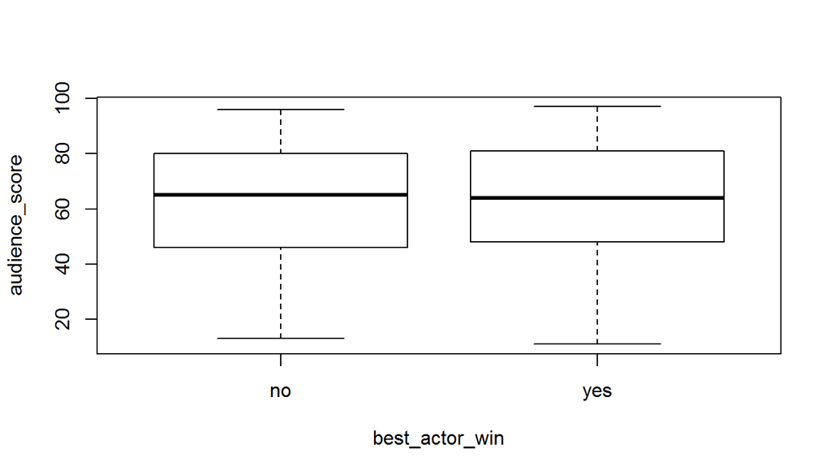

```r
plot(movies$best_actor_win,movies_subset$audience_score,xlab="best_actor_win",ylab="audience_score")
```

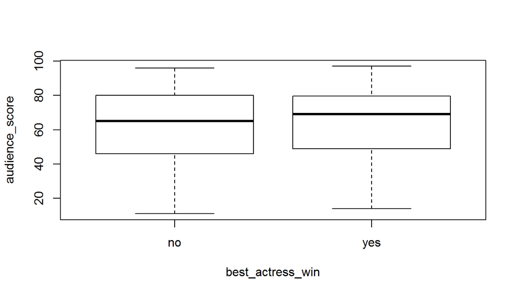

```r
plot(movies$best_actress_win,movies_subset$audience_score,xlab="best_actress_win",ylab="audience_score")
```

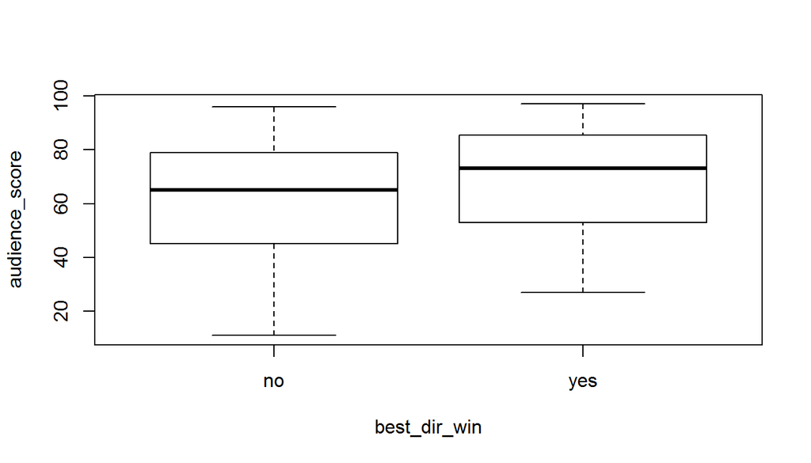

```r
plot(movies$best_dir_win,movies_subset$audience_score,xlab="best_dir_win",ylab="audience_score")
```

###### Narrative

The box plots for best_actor & best_actress win are very similar across the values of their variables . This can be considered as an indicator that these variables do not provide info to predict the variable . The best_actress_win vs audience score is negatively skewed when the value is “yes” The scores for a best director win have a higher median , smaller IQR and can be useful as a differentiator .

#### Impact of critic scores and imdb_ratings on audience scores

```r
cor(subset(movies,select = c("audience_score","critics_score","imdb_rating")))
```

```
##                audience_score critics_score imdb_rating
## audience_score      1.0000000     0.7042762   0.8648652
## critics_score       0.7042762     1.0000000   0.7650355
## imdb_rating         0.8648652     0.7650355   1.0000000
```

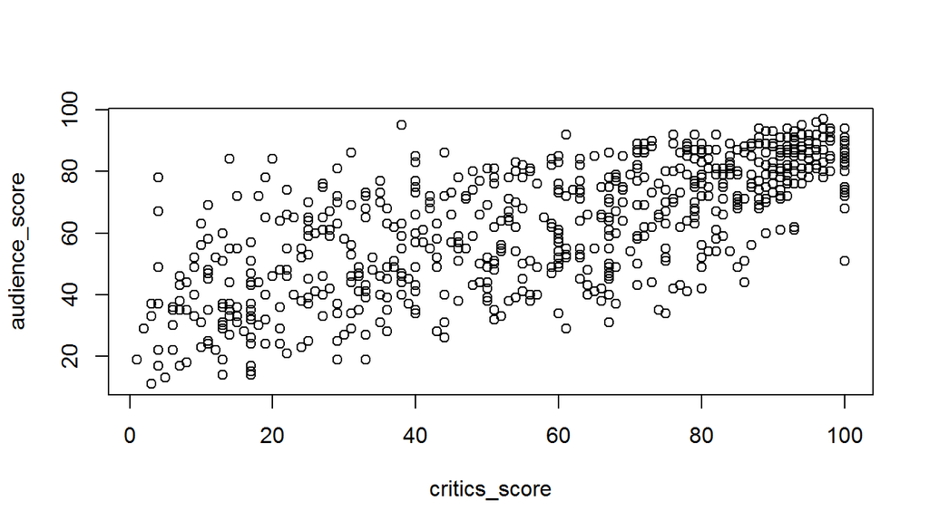

```r
plot(movies$critics_score,movies_subset$audience_score,xlab="critics_score",ylab="audience_score")
```

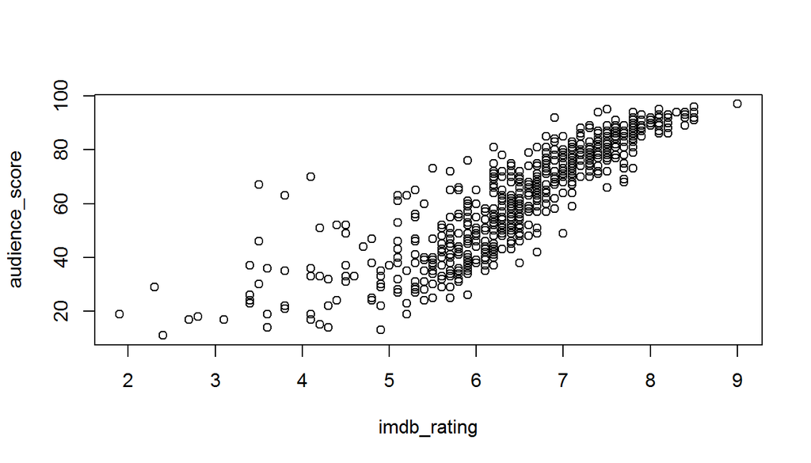

```r
plot(movies$imdb_rating,movies_subset$audience_score,xlab="imdb_rating",ylab="audience_score")
```

###### Narrative

I notice a very high correlation between the three variables .

The high correlation between imdb_rating and critics_score indicate that they might contain redundant information.

The high correlation with audience_score indicate that they might be very good predictors of the target .

#### correlation of runtime and imdb_ratings

```r
na_subset <- subset(movies,select = c("imdb_rating","runtime"))
cor(na_subset[!is.na(na_subset$runtime),])
```

```
##             imdb_rating   runtime
## imdb_rating   1.0000000 0.2682405
## runtime       0.2682405 1.0000000
```

[figure not shown]

```r
plot(movies$runtime,movies_subset$audience_score,xlab="runtime",ylab="imdb_rating")
```

## Part 4: Modeling

Our goal is to create a parsimonious model with a resonable goodness of fit .

I will be using MCMC since the model space is very large to study a model with all parameters.

```r
movies_subset_for_modelling <- subset(movies,select = c("audience_score","feature_film","drama","runtime","mpaa_rating_R","thtr_rel_year","oscar_season","summer_season","imdb_rating","imdb_num_votes","critics_score","best_pic_nom","best_pic_win","best_actor_win","best_actress_win","best_dir_win","top200_box"))

movies_bas = bas.lm(audience_score ~ ., movies_subset_for_modelling,prior = "BIC",method = "MCMC")
```

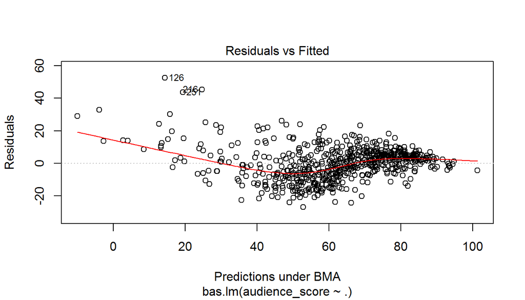

```r
plot(movies_bas,which = 1 )
```

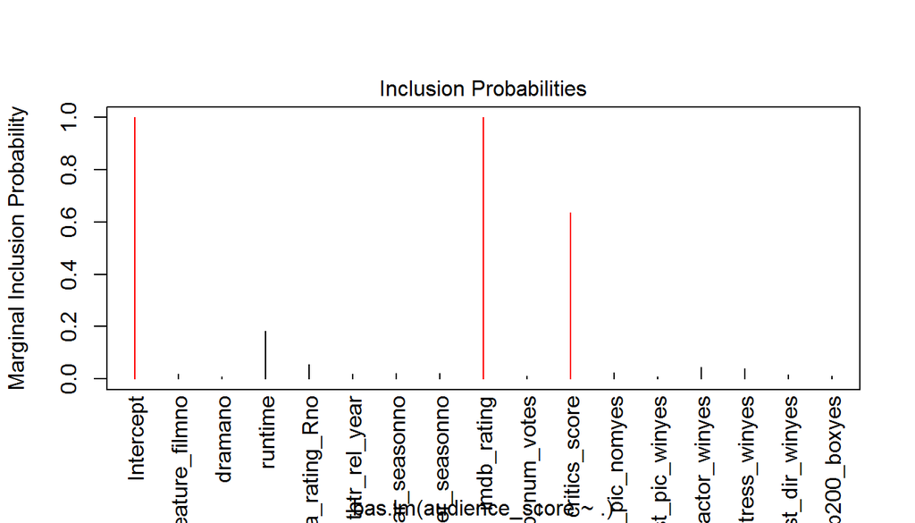

```r
plot(movies_bas,which = 4 )
```

I see that the residual plot suggest a huge number of outlier and hence the BMA model is questionable .

I know that having correlated variables tend to dampen the inclusion probabilities of other important variables so let us try removing imdb_rating as it contributes the most to the current model and run the diagnostics again .

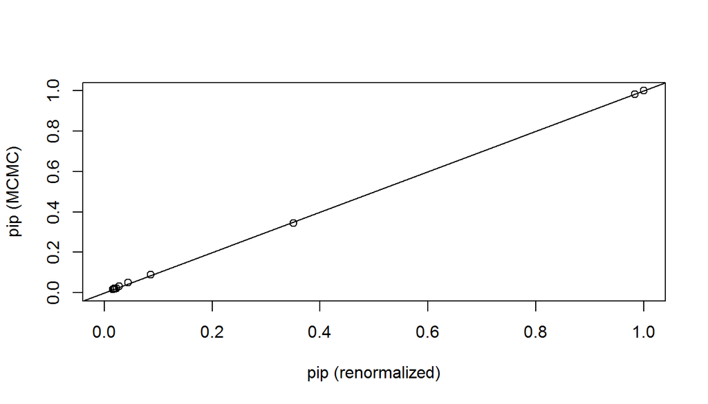

```r
movies_bas = bas.lm(audience_score ~ .- imdb_rating ,movies_subset_for_modelling,prior = "BIC",method = "MCMC")
diagnostics(movies_bas)
```

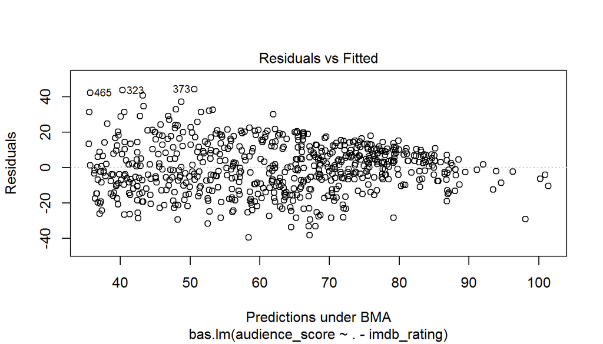

```r
plot(movies_bas,which = 1 , add.smooth = "F")
```

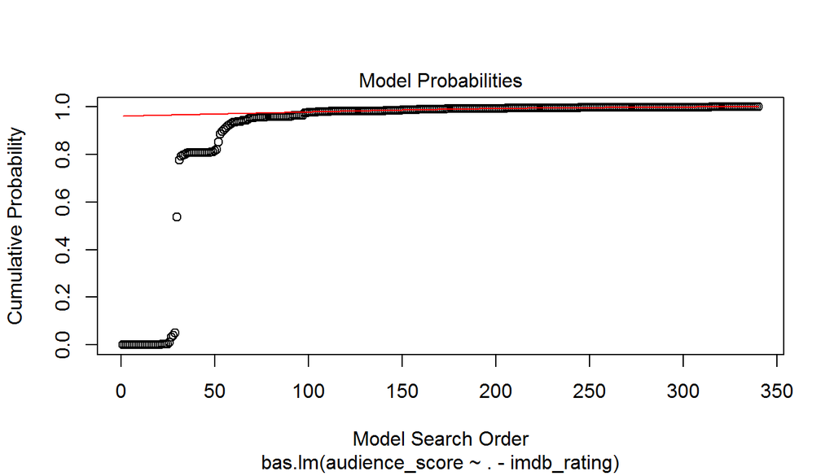

```r
plot(movies_bas,which = 2 )
```

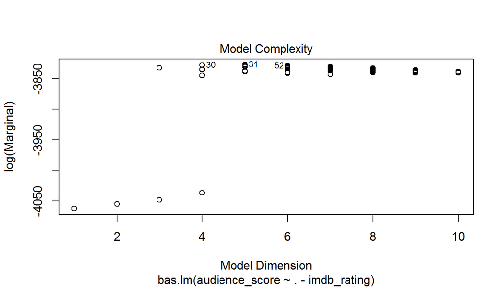

```r
plot(movies_bas,which = 3 )
```

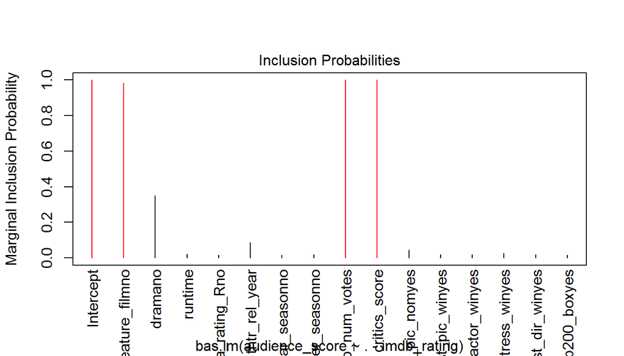

```r
plot(movies_bas,which = 4 )
```

From the above plots I notice the spread of the residuals is not uniform across the range of fitted values , leading us to believe the bma model is not good for prediction .

I also notice that a very small fraction of the sample space was discovered and the cumulative probability quickly tends to 1 .

I also get the highest bayes factor for a 4 predictor model .

The goal of this whole exercise is to develop a model that would best predict the audience_score / popularity . So under this context I need to choose the BPM model , Let us now look at the coefficients of the best predicitive model

```r
BPM = predict(movies_bas, estimator="BPM")
(movies_bas$namesx[attr(BPM$fit, 'model') +1])[-1]
```

```
## [1] "feature_filmno" "imdb_num_votes" "critics_score"
```

```r
movies_coef = coef(movies_bas)
movies_frame = data.frame(cbind(movies_coef$conditionalmeans[BPM$best,],movies_coef$conditionalsd[BPM$best,]),row.names = movies_coef$namesx)
colnames(movies_frame) = c("conditional_mean","conditional_std")
movies_frame
```

```
##                     conditional_mean conditional_std
## Intercept               6.234769e+01    5.458780e-01
## feature_filmno          8.393322e+00    2.062192e+00
## dramano                 0.000000e+00    0.000000e+00
## runtime                 0.000000e+00    0.000000e+00
## mpaa_rating_Rno         0.000000e+00    0.000000e+00
## thtr_rel_year           0.000000e+00    0.000000e+00
## oscar_seasonno          0.000000e+00    0.000000e+00
## summer_seasonno         0.000000e+00    0.000000e+00
## imdb_num_votes          3.171424e-05    5.120671e-06
## critics_score           4.480090e-01    2.110890e-02
## best_pic_nomyes         0.000000e+00    0.000000e+00
## best_pic_winyes         0.000000e+00    0.000000e+00
## best_actor_winyes       0.000000e+00    0.000000e+00
## best_actress_winyes     0.000000e+00    0.000000e+00
## best_dir_winyes         0.000000e+00    0.000000e+00
## top200_boxyes           0.000000e+00    0.000000e+00
```

The best predictive model consists of of only 3 predictors feature_film , critics_score , imdb_num_voes

This also happens to be the Median probability model as it consists of predictors having inclusion probabilities over 0.5

The coefficient of imdb_num_votes suggest that the model is sensitive to movies with high number of votes , this makes sense as a lower number of votes do signify a lower popularity in terms of reach .

## Part 5: Prediction

I will be using the BPM model developed in the previous section to predict the audience_score of Captain America : Civil War(20160.

Our model only depends on feature_film , imdb_num_votes and critics_score since this was the BPM .

```r
small_predictive_model = bas.lm(audience_score ~ feature_film + imdb_num_votes + critics_score,movies_subset_for_modelling,prior = "BIC")

new_vector = data.frame(audience_score = 89 , feature_film = "yes",critics_score=90,imdb_num_votes = 377545)
new_vector$feature_film = factor(new_vector$feature_film,levels = c("yes","no"))
prediction = predict(small_predictive_model,newdata = new_vector, estimator="BPM",se.fit = TRUE )

prediction$Ybma
```

```
##          [,1]
## [1,] 86.22618
```

## Part 6: Conclusion

Predicting movie popularity is not trivial .

We arrived at a model with feature_film , critics_score and num_votes but other seemingly important factors like best_pic_nom , best_actor_win etc received very low inclusion probabilities which I believe is partly due to the low percentage of observations for those cases i.e a more accurate model could have been developed if we had more observations .

Other data points that would have made a good addition to the dataset would be the number of critics that reviewed a movie , it gives a credibility to the score and the number of awards the specific movie won , it could increase its popularity later by fueling DVD sales .